# Marketing Anlytics Project

```r
# Install and load all the packages we need
library('VIM')
library(readr)
library(tidyverse)
library(dplyr)
```

### 1. Introduction

#### Objective:

- Look at the distribution of customers demographcis
- Find how is purchase differed w.r.t. demographcis factors and test it
- what kind of products are sold well and who is buying them (to be decided)

### 2. Data Description

#### a. Describe the conceptual measure types of the different variables

```r
BF =  read_csv("BlackFriday.csv")
```

- User_ID : discrete
- Product_ID : discrete
- Gender : discrete
- Age : discrete
- Occupation : discrete
- City_Category : discrete
- Stay_in_Current_City_Years : continuous
- Marital_Status : discrete
- Product_Category_1 : discrete
- Product_Category_2 : discrete
- Product_Category_3 : discrete
- and finally Purchase :continuous

#### b. Mention all the steps you took to clean the data

##### Step 1. Check if the data contains missing values

```r
sum(complete.cases(BF))
```

```
## [1] 164278
```

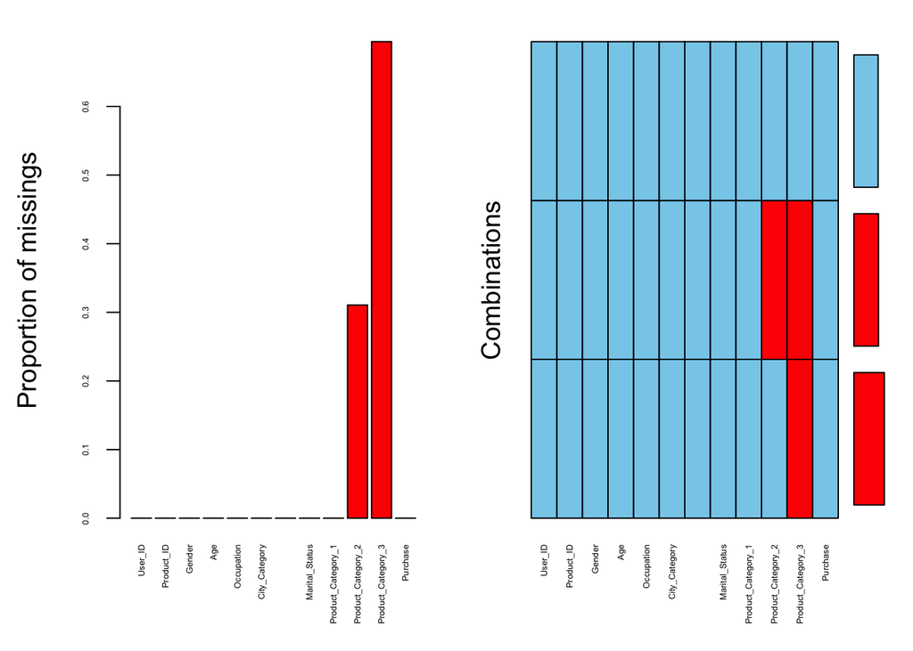

```r
aggr(BF,cex.axis = .4)
```

##### Step 2. Check the structure of the data

```r
summary(BF)
```

```
##     User_ID         Product_ID           Gender
##  Min.   :1000001   Length:537577      Length:537577
##  1st Qu.:1001495   Class :character   Class :character
##  Median :1003031   Mode  :character   Mode  :character
##  Mean   :1002992
##  3rd Qu.:1004417
##  Max.   :1006040
##
##      Age              Occupation     City_Category
##  Length:537577      Min.   : 0.000   Length:537577
##  Class :character   1st Qu.: 2.000   Class :character
##  Mode  :character   Median : 7.000   Mode  :character
##                     Mean   : 8.083
##                     3rd Qu.:14.000
##                     Max.   :20.000
##
##  Stay_In_Current_City_Years Marital_Status   Product_Category_1
##  Length:537577              Min.   :0.0000   Min.   : 1.000
##  Class :character           1st Qu.:0.0000   1st Qu.: 1.000
##  Mode  :character           Median :0.0000   Median : 5.000
##                             Mean   :0.4088   Mean   : 5.296
##                             3rd Qu.:1.0000   3rd Qu.: 8.000
##                             Max.   :1.0000   Max.   :18.000
##
##  Product_Category_2 Product_Category_3    Purchase
##  Min.   : 2.00      Min.   : 3.0       Min.   :  185
##  1st Qu.: 5.00      1st Qu.: 9.0       1st Qu.: 5866
##  Median : 9.00      Median :14.0       Median : 8062
##  Mean   : 9.84      Mean   :12.7       Mean   : 9334
##  3rd Qu.:15.00      3rd Qu.:16.0       3rd Qu.:12073
##  Max.   :18.00      Max.   :18.0       Max.   :23961
##  NA's   :166986     NA's   :373299
```

```r
str(BF)
```

```
## Classes 'tbl_df', 'tbl' and 'data.frame':    537577 obs. of  12 variables:
##  $ User_ID                   : int  1000001 1000001 1000001 1000001 1000002 1000003 1000004 1000004 1000004 1000005 ...
##  $ Product_ID                : chr  "P00069042" "P00248942" "P00087842" "P00085442" ...
##  $ Gender                    : chr  "F" "F" "F" "F" ...
##  $ Age                       : chr  "0-17" "0-17" "0-17" "0-17" ...
##  $ Occupation                : int  10 10 10 10 16 15 7 7 7 20 ...
##  $ City_Category             : chr  "A" "A" "A" "A" ...
##  $ Stay_In_Current_City_Years: chr  "2" "2" "2" "2" ...
##  $ Marital_Status            : int  0 0 0 0 0 0 1 1 1 1 ...
##  $ Product_Category_1        : int  3 1 12 12 8 1 1 1 1 8 ...
##  $ Product_Category_2        : int  NA 6 NA 14 NA 2 8 15 16 NA ...
##  $ Product_Category_3        : int  NA 14 NA NA NA NA 17 NA NA NA ...
##  $ Purchase                  : int  8370 15200 1422 1057 7969 15227 19215 15854 15686 7871 ...
##  - attr(*, "spec")=List of 2
##   ..$ cols   :List of 12
##   .. ..$ User_ID                   : list()
##   .. .. ..- attr(*, "class")= chr  "collector_integer" "collector"
##   .. ..$ Product_ID                : list()
##   .. .. ..- attr(*, "class")= chr  "collector_character" "collector"
##   .. ..$ Gender                    : list()
##   .. .. ..- attr(*, "class")= chr  "collector_character" "collector"
##   .. ..$ Age                       : list()
##   .. .. ..- attr(*, "class")= chr  "collector_character" "collector"
##   .. ..$ Occupation                : list()
##   .. .. ..- attr(*, "class")= chr  "collector_integer" "collector"
##   .. ..$ City_Category             : list()
##   .. .. ..- attr(*, "class")= chr  "collector_character" "collector"
##   .. ..$ Stay_In_Current_City_Years: list()
##   .. .. ..- attr(*, "class")= chr  "collector_character" "collector"
##   .. ..$ Marital_Status            : list()
##   .. .. ..- attr(*, "class")= chr  "collector_integer" "collector"
##   .. ..$ Product_Category_1        : list()
##   .. .. ..- attr(*, "class")= chr  "collector_integer" "collector"
##   .. ..$ Product_Category_2        : list()
##   .. .. ..- attr(*, "class")= chr  "collector_integer" "collector"
##   .. ..$ Product_Category_3        : list()
##   .. .. ..- attr(*, "class")= chr  "collector_integer" "collector"
##   .. ..$ Purchase                  : list()
##   .. .. ..- attr(*, "class")= chr  "collector_integer" "collector"
##   ..$ default: list()
##   .. ..- attr(*, "class")= chr  "collector_guess" "collector"
##   ..- attr(*, "class")= chr "col_spec"
```

#### Step 3. Type coercion

```r
BF[1:11] = lapply(BF[1:11], factor)
```

#### Step 4. Tidy the data

```r
# Demographics data
demo = BF %>%
  select(-starts_with("Product")) %>%
  group_by(User_ID) %>%
  mutate(Purchase = sum(Purchase))

demo = demo[!duplicated(demo$User_ID), ]
```

### 3. Summary statistics and Data Visualizations

> ** Customer Demographics**  
> * The distribution of gender and maritial status

```r
# Two way frequency table showing different combination of customers using gender and marital status
customer = table(demo$Gender, demo$Marital_Status)
colnames(customer) = c("Unmarried", "Married")
rownames(customer) = c("Female", "Male")

addmargins(customer)
```

```
##
##          Unmarried Married  Sum
##   Female       947     719 1666
##   Male        2470    1755 4225
##   Sum         3417    2474 5891
```

```r
addmargins(prop.table(customer))
```

```
##
##          Unmarried   Married       Sum
##   Female 0.1607537 0.1220506 0.2828043
##   Male   0.4192837 0.2979121 0.7171957
##   Sum    0.5800373 0.4199627 1.0000000
```

The two-way frequency table shows 4 combinations of customers. There are 5891 distinct customers in total, and 2470 of them are unmarried male; 1755 are married male; 947 are unmarried female; 719 are married female.  
In this two-frequency table, we can figure out that there are more unmarried customers (58%) than the married (42%) and more male customers (72%) than the female (28%). Therefore, in the following analysis about gender and maritial status, we need to focus on their average purchase instead of the sum purchase, because the sum purchase will easily be influenced by the number of people, which may caused a biased conclusion.

** Distribution of purchase**

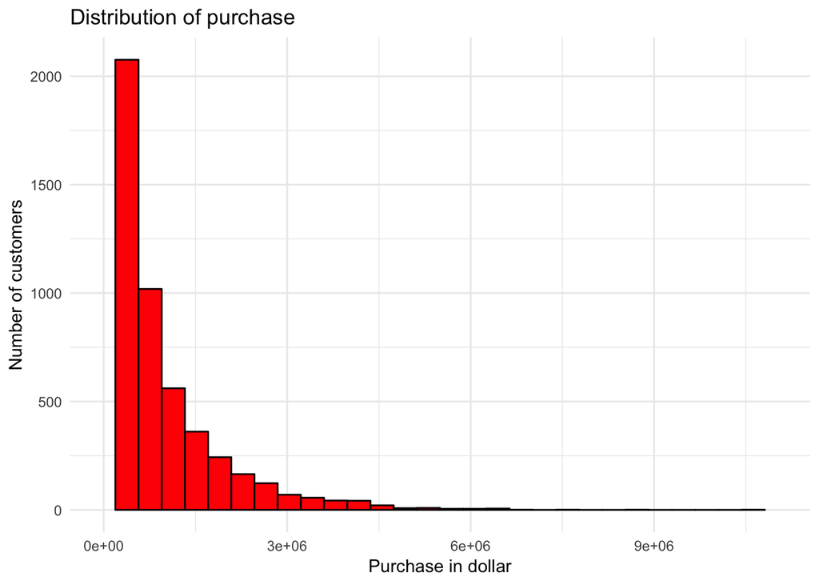

```r
demo %>%
  ggplot(aes(Purchase)) +
  geom_histogram(col = "black", fill = "red1") +
  scale_x_continuous(limits = c(0, 11000000)) +
  theme_minimal() +
  labs(x = "Purchase in dollar", y = "Number of customers", title = "Distribution of purchase")
```

** Purchase disttribution by gender and city**

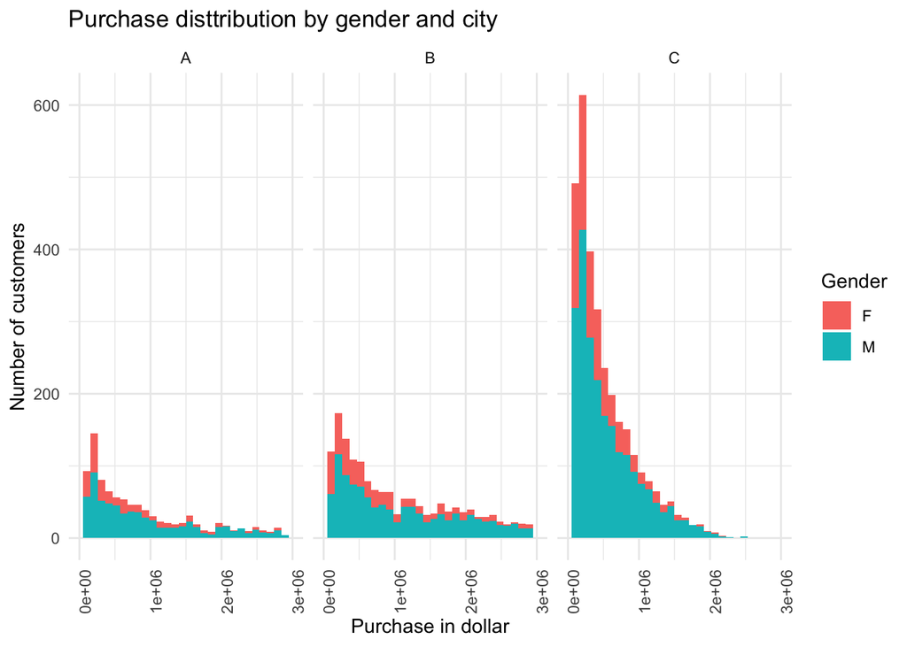

```r
demo %>%
  ggplot(aes(x = Purchase, fill = Gender)) +
  geom_histogram() +
  facet_grid(~City_Category) +
  scale_x_continuous(limits = c(0, 3000000)) +
  theme_minimal() +
  labs(x = "Purchase in dollar", y = "Number of customers", title = "Purchase disttribution by gender and city")+
  theme(axis.text.x = element_text(angle = 90, hjust = 0.5))
```

** Purchase distribution by occupation**

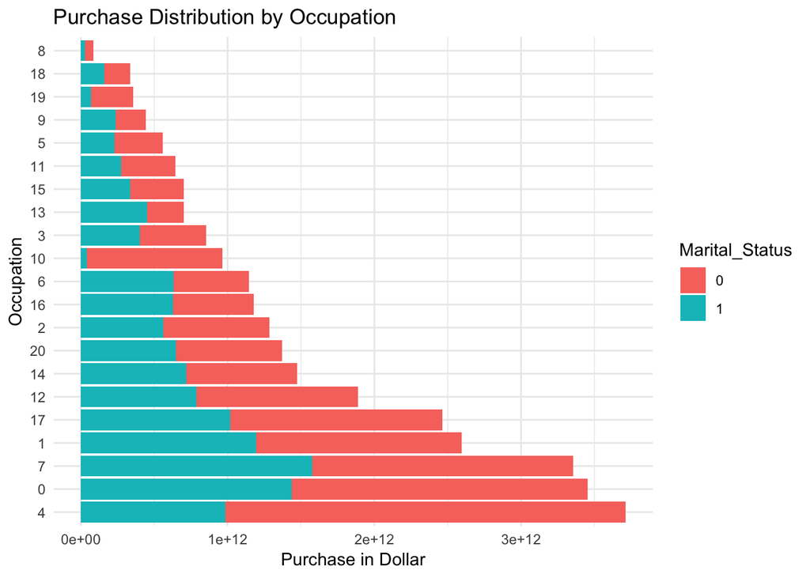

```r
demo %>%
  group_by(Occupation)%>%
  ggplot(aes(x = fct_infreq(Occupation), y = sum(Purchase), fill = Marital_Status)) +
  geom_bar(stat = "identity") +
  theme_minimal() +
  coord_flip() +
  labs(x = "Occupation", y = "Purchase in Dollar", title = "Purchase Distribution by Occupation")
```

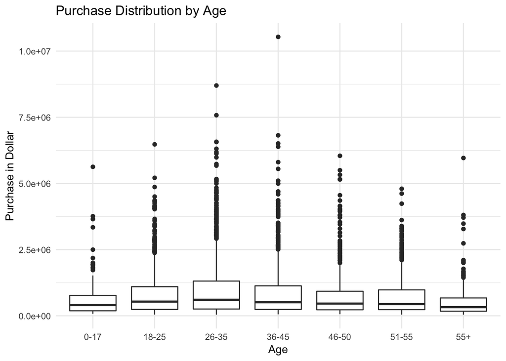

```r
demo %>%
  ggplot(aes(x = Age, y = Purchase)) +
  geom_boxplot() +
  theme_minimal() +
  labs(x = "Age", y = "Purchase in Dollar", title = "Purchase Distribution by Age")
```

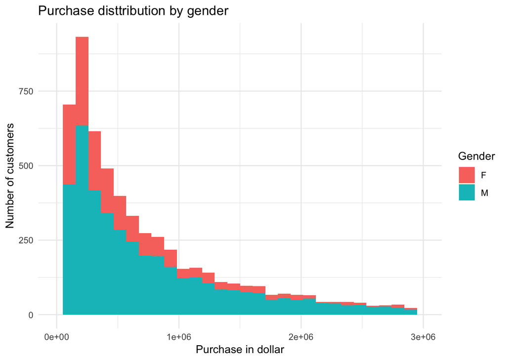

```r
demo %>%
  ggplot(aes(x = Purchase, fill = Gender)) +
  geom_histogram() +
  scale_x_continuous(limits = c(0, 3000000)) +
  theme_minimal() +
  labs(x = "Purchase in dollar", y = "Number of customers", title = "Purchase disttribution by gender")
```

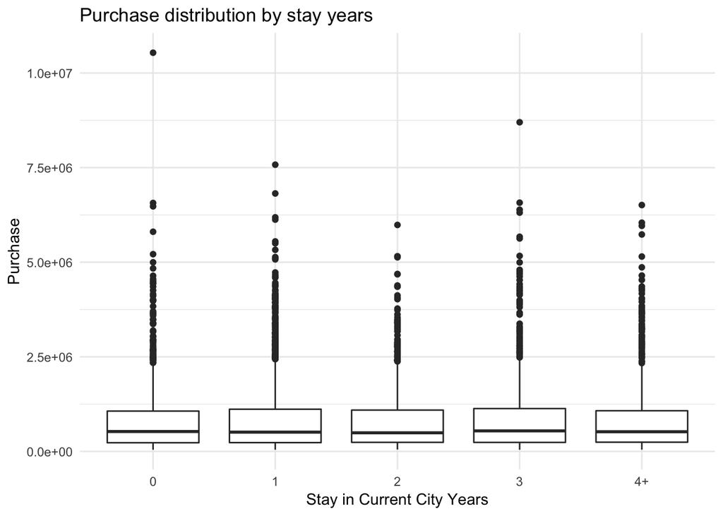

```r
demo %>%
  ggplot(aes(x = Stay_In_Current_City_Years, y = Purchase)) +
  geom_boxplot()+
  theme_minimal() +
  labs(x = "Stay in Current City Years", y = "Purchase", title = "Purchase distribution by stay years")
```

** What’s the most popular product category?** The product category 1 has three most popular product: 5, 1 and 8 - Bar graphs

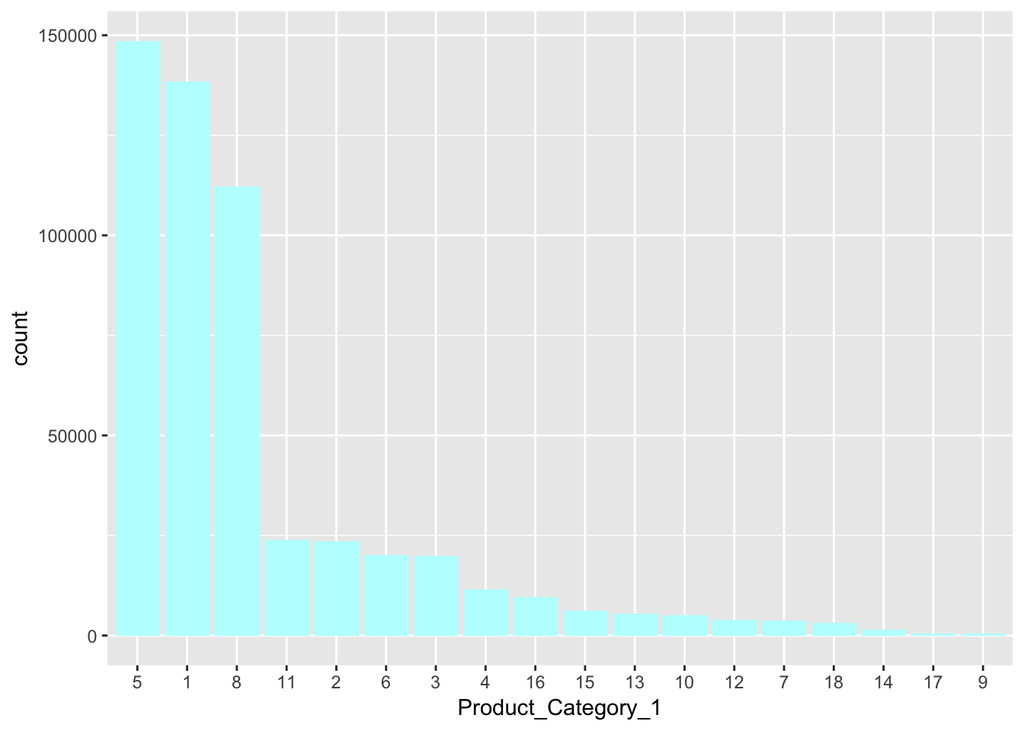

```r
BF_prt = BF %>%
  group_by(Product_ID) %>%
  mutate(sumpp = sum(Purchase), avgpp = mean(Purchase))
BF_prt = BF_prt[-c(3:8)]
BF_prt%>%
  ggplot(aes(x = Product_Category_1))+
  geom_bar(aes(x = fct_infreq(as.factor(Product_Category_1))),fill = 'paleturquoise1')
```

### 4 Preliminary statistical analyses

```r
## Independent t test
# Does men spend more money on Black Friday than women?
t.test(demo[demo$Gender == "M", ]$Purchase,
       demo[demo$Gender == "F", ]$Purchase,
       paired = FALSE,
       alternative = "greater")
```

```
##
##  Welch Two Sample t-test
##
## data:  demo[demo$Gender == "M", ]$Purchase and demo[demo$Gender == "F", ]$Purchase
## t = 8.6542, df = 3709.2, p-value < 2.2e-16
## alternative hypothesis: true difference in means is greater than 0
## 95 percent confidence interval:
##  172432.4      Inf
## sample estimates:
## mean of x mean of y
##  911963.2  699054.0
```

```r
## Independent t test
# Does unmarried customers spend more money on Black Friday than the married?
t.test(demo[demo$Marital_Status == 0, ]$Purchase,
       demo[demo$Marital_Status == 1, ]$Purchase,
       paired = FALSE,
       alternative = "greater")
```

```
##
##  Welch Two Sample t-test
##
## data:  demo[demo$Marital_Status == 0, ]$Purchase and demo[demo$Marital_Status == 1, ]$Purchase
## t = 1.5859, df = 5392.3, p-value = 0.05641
## alternative hypothesis: true difference in means is greater than 0
## 95 percent confidence interval:
##  -1454.306       Inf
## sample estimates:
## mean of x mean of y
##  868097.6  829175.0
```

```r
### Chi square test
## Is there an association between age and purchase?

# Creat purchase category
demo = demo %>%
  mutate(purchase_category = cut(Purchase, breaks = c(-Inf, 234914, 512612, 1099005, Inf),
                                        labels = c("low", "middle", "high", "very high")))

# Creat two way frequency table
table(demo$Age, demo$purchase_category)
```

```
##
##         low middle high very high
##   0-17   67     62   59        30
##   18-25 257    263  282       267
##   26-35 457    455  519       622
##   36-45 280    304  273       310
##   46-50 145    147  138       101
##   51-55 126    132  120       103
##   55+   141    110   81        40
```

```r
# Apply chi square test
chisq.test(table(demo$Age, demo$purchase_category))
```

```
##
##  Pearson's Chi-squared test
##
## data:  table(demo$Age, demo$purchase_category)
## X-squared = 129.75, df = 18, p-value < 2.2e-16
```